# Análisis evolución Covid-19 (21/03/2020)

Claudio Bustos

21/3/2020

**NOTA**: Lo que presento aquí es un ejemplo de como realizar análisis de series de tiempo, usando datos de la evolución total de casos disponible en fuentes públicas en internet. No tiene ninguna validez epidemiológica, ya que eso requería un modelo de la diseminación de la enfermedad. En particular, las predicciones son solo válidas en cuanto no existan cambios en las políticas públicas; si los hay, se esperaría que (ojalá) las predicciones fuesen incorrectas.

- **Informe día 20/03/2020**: https://rpubs.com/clbustos/587389

## Análisis de datos observados

Se utiliza una escala logarítmica, que permite mejor apreciar las tendencias en los casos totales, además de partir en todos los países con al menos 20 casos. Italia presenta una disminución constante de su tasa de contagio, en tanto que España parece que no logrará disminuir la tasa de contagio con respecto a Italia. Chile muestra una leve disminución en su tasa, pasando de 46% de ayer 20 a 44.6%

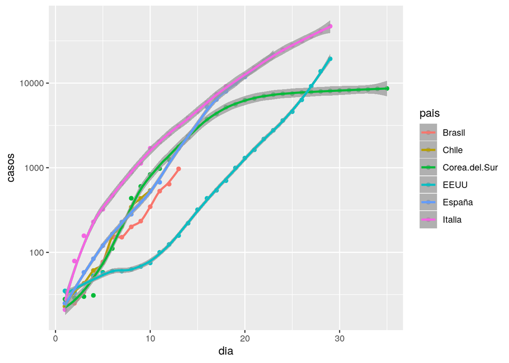

Ajustando una regresión exponencial, esta representa bastante bien todavía la situación de Chile, como la de Brasil. En el caso de Chile, una tasa de 44.6% de aumento diario indicaría una duplicación de casos cada 1.88 días.

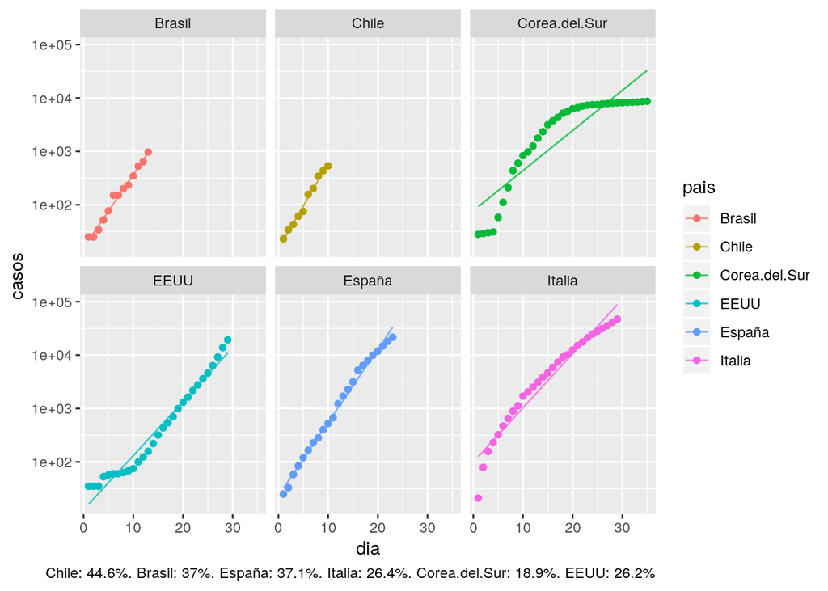

Graficando la tasa de nuevos casos usando media móvil con ventana de 3 días, se observa con mayor claridad el estancamiento de España, así como el aumento de la tasa de Brasil.

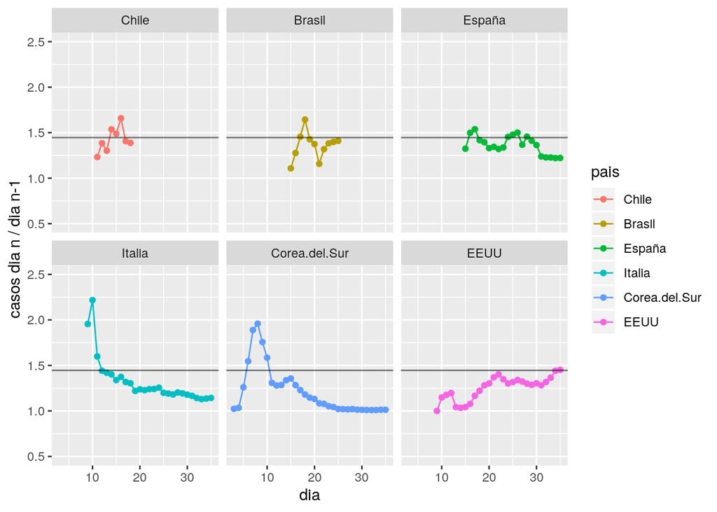

## Predicción

**NOTA**: Se presentan aquí tres metodologías de predicción. Recuerden que corresponden a un ejercicio para mostrar las bondades y dificultades de cada técnica

Para predecir, se ocupan tres técnicas distintas:

- regresión exponencial sobre datos totales: se ajusta la serie a la expresión $y=a * r^t$ usando regresión lineal. Es válida si el proceso no cambia a lo largo del tiempo. Se caracteriza porque el intervalo de confianza es constante al transformar los datos a logaritmo.
- tendencia sobre casos nuevos + AR(1): Se modela la tendencia de los casos nuevos usando regresión exponencial, más la relación que existe entre dos mediciones contiguas. El error estándar aumenta de manera importante a lo largo del tiempo, tanto por el error al calcular la tendencia, como por el componente AR(1). El valor medio obtenido es bastante sensible a los cambios en las mediciones finales.
- ARIMA(1,1,0) más deriva: Se ocupa un modelo autorregresivo, con diferenciación y deriva. Esto implica que se asume que los datos tienen una tendencia constante (como el modelo de regresión exponencial), y que lo que modela es el cambio (como el modelo de tendencia). Tiende a generar modelos menos variables que el tendencia + AR(1), pero también es menos sensible a los cambios más recientes de tendencia

La disminución en la tasa de nuevos casos en Chile se ve reflejada en una curva de tendencia + AR relativamente optimista, respecto al modelo exponencial. Sin embargo, las quejas del Colegio Médico respecto a la saturación de la capacidad diagnóstica hacen ser cautos con las predicciones. Preocupa el caso de Brasil, donde el modelo AR tiende a mostrar que deberían existir aun más casos que los que predice el modelo exponencial.

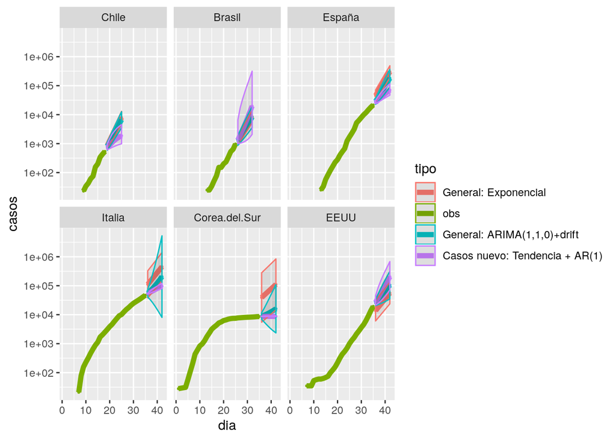

A continuación, se presentan las predicciones para los próximos 7 días, usando tendencia de datos nuevos + AR(1), que tiende a ser bastante sensible a la evolución de los últimos días. Considerando lo breve de la escala de tiempo, el intervalo de confianza se vuelve muy grande pasado tres días para Chile y Brasil, no así para los países con línea de tiempo mayores.

Tendencia + AR(1) : Chile

|  | dia | casos | li | ls |
| --- | --- | --- | --- | --- |
| **11** | 19 | 710.5 | 560.3 | 1829 |
| **12** | 20 | 881.3 | 571.5 | 4425 |
| **13** | 21 | 1094 | 578 | 11442 |
| **14** | 22 | 1315 | 580.8 | 29013 |
| **15** | 23 | 1556 | 581.9 | 80637 |
| **16** | 24 | 1797 | 582.3 | 238525 |
| **17** | 25 | 2037 | 582.4 | 775634 |

Tendencia + AR(1) : Brasil

|  | dia | casos | li | ls |
| --- | --- | --- | --- | --- |
| **14** | 26 | 1324 | 972.5 | 51431 |
| **15** | 27 | 1899 | 973.9 | 285532 |
| **16** | 28 | 2734 | 974.6 | 1343639 |
| **17** | 29 | 3984 | 974.8 | 7091728 |
| **18** | 30 | 5841 | 974.9 | 43156752 |
| **19** | 31 | 8609 | 975 | 306938477 |
| **20** | 32 | 12736 | 975 | 2.546e+09 |

Tendencia + AR(1) : España

|  | dia | casos | li | ls |
| --- | --- | --- | --- | --- |
| **24** | 36 | 26275 | 23229 | 34916 |
| **25** | 37 | 31761 | 25004 | 51867 |
| **26** | 38 | 38038 | 26854 | 73170 |
| **27** | 39 | 45135 | 28742 | 99853 |
| **28** | 40 | 53065 | 30630 | 133166 |
| **29** | 41 | 61825 | 32481 | 174612 |
| **30** | 42 | 71389 | 34261 | 225993 |

Tendencia + AR(1) : Italia

|  | dia | casos | li | ls |
| --- | --- | --- | --- | --- |
| **30** | 36 | 52822 | 50189 | 57644 |
| **31** | 37 | 59243 | 53534 | 69969 |
| **32** | 38 | 66055 | 56945 | 83574 |
| **33** | 39 | 73302 | 60425 | 98665 |
| **34** | 40 | 80943 | 63933 | 115304 |
| **35** | 41 | 88950 | 67439 | 133593 |
| **36** | 42 | 97285 | 70909 | 153614 |

Tendencia + AR(1) : Corea.del.Sur

|  | dia | casos | li | ls |
| --- | --- | --- | --- | --- |
| **36** | 36 | 8687 | 8655 | 9077 |
| **37** | 37 | 8703 | 8656 | 9370 |
| **38** | 38 | 8711 | 8656 | 9553 |
| **39** | 39 | 8714 | 8656 | 9666 |
| **40** | 40 | 8716 | 8656 | 9735 |
| **41** | 41 | 8717 | 8656 | 9776 |
| **42** | 42 | 8718 | 8656 | 9802 |

Tendencia + AR(1) : EEUU

|  | dia | casos | li | ls |
| --- | --- | --- | --- | --- |
| **30** | 36 | 26994 | 20502 | 70609 |
| **31** | 37 | 37636 | 21864 | 153799 |
| **32** | 38 | 52594 | 23552 | 286302 |
| **33** | 39 | 73685 | 25638 | 499539 |
| **34** | 40 | 103491 | 28198 | 846583 |
| **35** | 41 | 145690 | 31317 | 1417583 |
| **36** | 42 | 205548 | 35090 | 2367132 |

Ahora, la predicción por método exponencial, que tiende a funcionar bien para procesos sin cambios recientes.

Exponencial : Chile

|  | dia | casos | li | ls |
| --- | --- | --- | --- | --- |
| **11** | 19 | 870 | 605.2 | 1251 |
| **12** | 20 | 1258 | 860 | 1840 |
| **13** | 21 | 1819 | 1219 | 2714 |
| **14** | 22 | 2631 | 1726 | 4009 |
| **15** | 23 | 3804 | 2441 | 5929 |
| **16** | 24 | 5501 | 3446 | 8781 |
| **17** | 25 | 7955 | 4861 | 13019 |

Exponencial : Brasil

|  | dia | casos | li | ls |
| --- | --- | --- | --- | --- |
| **14** | 26 | 1296 | 877.1 | 1914 |
| **15** | 27 | 1776 | 1188 | 2654 |
| **16** | 28 | 2433 | 1607 | 3684 |
| **17** | 29 | 3334 | 2171 | 5120 |
| **18** | 30 | 4568 | 2931 | 7121 |
| **19** | 31 | 6260 | 3953 | 9913 |
| **20** | 32 | 8578 | 5327 | 13811 |

Exponencial : España

|  | dia | casos | li | ls |
| --- | --- | --- | --- | --- |
| **24** | 36 | 45475 | 29077 | 71119 |
| **25** | 37 | 62353 | 39685 | 97969 |
| **26** | 38 | 85496 | 54146 | 134997 |
| **27** | 39 | 117228 | 73852 | 186078 |
| **28** | 40 | 160737 | 100702 | 256564 |
| **29** | 41 | 220396 | 137273 | 353851 |
| **30** | 42 | 302197 | 187074 | 488163 |

Exponencial : Italia

|  | dia | casos | li | ls |
| --- | --- | --- | --- | --- |
| **30** | 36 | 111275 | 37919 | 326537 |
| **31** | 37 | 140652 | 47589 | 415707 |
| **32** | 38 | 177784 | 59699 | 529444 |
| **33** | 39 | 224720 | 74861 | 674571 |
| **34** | 40 | 284047 | 93837 | 859815 |
| **35** | 41 | 359036 | 117578 | 1096351 |
| **36** | 42 | 453822 | 147270 | 1398482 |

Exponencial : Corea.del.Sur

|  | dia | casos | li | ls |
| --- | --- | --- | --- | --- |
| **36** | 36 | 39218 | 5494 | 279974 |
| **37** | 37 | 46625 | 6472 | 335884 |
| **38** | 38 | 55430 | 7621 | 403138 |
| **39** | 39 | 65898 | 8971 | 484071 |
| **40** | 40 | 78343 | 10555 | 581503 |
| **41** | 41 | 93138 | 12413 | 698844 |
| **42** | 42 | 110728 | 14592 | 840216 |

Exponencial : EEUU

|  | dia | casos | li | ls |
| --- | --- | --- | --- | --- |
| **30** | 36 | 13788 | 6084 | 31246 |
| **31** | 37 | 17403 | 7638 | 39653 |
| **32** | 38 | 21966 | 9585 | 50339 |
| **33** | 39 | 27726 | 12026 | 63925 |
| **34** | 40 | 34996 | 15083 | 81201 |
| **35** | 41 | 44172 | 18911 | 103175 |
| **36** | 42 | 55755 | 23705 | 131134 |

El modelo ARIMA(1,1,0) más deriva mantiene la tendencia del modelo exponencial, pero corrigiendo los errores estándar en función de la inestabilidad de las mediciones contiguas.

ARIMA(1,1,0) con deriva : Chile

|  | dia | casos | li | ls |
| --- | --- | --- | --- | --- |
| **11** | 19 | 815.4 | 587.7 | 1131 |
| **12** | 20 | 1128 | 776.9 | 1638 |
| **13** | 21 | 1628 | 1041 | 2545 |
| **14** | 22 | 2305 | 1403 | 3785 |
| **15** | 23 | 3292 | 1906 | 5686 |
| **16** | 24 | 4682 | 2595 | 8450 |
| **17** | 25 | 6673 | 3546 | 12555 |

ARIMA(1,1,0) con deriva : Brasil

|  | dia | casos | li | ls |
| --- | --- | --- | --- | --- |
| **14** | 26 | 1284 | 872.6 | 1889 |
| **15** | 27 | 1760 | 1089 | 2847 |
| **16** | 28 | 2392 | 1348 | 4242 |
| **17** | 29 | 3257 | 1701 | 6234 |
| **18** | 30 | 4432 | 2161 | 9090 |
| **19** | 31 | 6033 | 2763 | 13174 |
| **20** | 32 | 8212 | 3549 | 19004 |

ARIMA(1,1,0) con deriva : España

|  | dia | casos | li | ls |
| --- | --- | --- | --- | --- |
| **24** | 36 | 28815 | 22738 | 36515 |
| **25** | 37 | 39054 | 27325 | 55819 |
| **26** | 38 | 53032 | 33865 | 83047 |
| **27** | 39 | 72030 | 42634 | 121694 |
| **28** | 40 | 97837 | 54196 | 176620 |
| **29** | 41 | 132890 | 69357 | 254621 |
| **30** | 42 | 180502 | 89206 | 365234 |

ARIMA(1,1,0) con deriva : Italia

|  | dia | casos | li | ls |
| --- | --- | --- | --- | --- |
| **30** | 36 | 55009 | 40402 | 74899 |
| **31** | 37 | 65632 | 33394 | 128995 |
| **32** | 38 | 79779 | 26342 | 241614 |
| **33** | 39 | 98701 | 20120 | 484192 |
| **34** | 40 | 124171 | 15024 | 1026219 |
| **35** | 41 | 158707 | 11045 | 2280428 |
| **36** | 42 | 205919 | 8036 | 5276765 |

ARIMA(1,1,0) con deriva : Corea.del.Sur

|  | dia | casos | li | ls |
| --- | --- | --- | --- | --- |
| **36** | 36 | 9001 | 6947 | 11661 |
| **37** | 37 | 9581 | 5647 | 16254 |
| **38** | 38 | 10382 | 4603 | 23415 |
| **39** | 39 | 11408 | 3797 | 34275 |
| **40** | 40 | 12672 | 3182 | 50469 |
| **41** | 41 | 14197 | 2712 | 74301 |
| **42** | 42 | 16009 | 2352 | 108969 |

ARIMA(1,1,0) con deriva : EEUU

|  | dia | casos | li | ls |
| --- | --- | --- | --- | --- |
| **30** | 36 | 25797 | 20705 | 32141 |
| **31** | 37 | 33361 | 22240 | 50043 |
| **32** | 38 | 42450 | 23897 | 75407 |
| **33** | 39 | 53535 | 25906 | 110629 |
| **34** | 40 | 67184 | 28394 | 158968 |
| **35** | 41 | 84088 | 31453 | 224804 |
| **36** | 42 | 105088 | 35172 | 313985 |

Fuentes de información:

- Chile: https://www.minsal.cl/nuevo-coronavirus-2019-ncov/casos-confirmados-en-chile-covid-19/.
- Otros países: https://www.worldometers.info/coronavirus/#countries
- Presidenta del Colegio Médico golpea la mesa y acusa “total falta de transparencia” en el manejo del Gobierno en la crisis del coronavirus: https://www.elmostrador.cl/noticias/pais/2020/03/20/presidenta-del-colegio-medico-golpea-la-mesa-y-acusa-total-falta-de-transparencia-en-el-manejo-del-gobierno-en-la-crisis-del-coronavirus/